# Risk Factor Analysis

## Outcome Variable

**Outcome Variable:** haz

## Predictor Variables

**Intervention Variable:** mbmi

**Adjustment Set:**

unadjusted

## Stratifying Variables

The analysis was stratified on these variable(s):

- agecat
- studyid
- country

## Data Summary

| agecat | studyid | country | mbmi | n_cell | n |
| --- | --- | --- | --- | --- | --- |
| Birth | ki0047075b-MAL-ED | BANGLADESH | Normal weight | 216 | 246 |
| Birth | ki0047075b-MAL-ED | BANGLADESH | Underweight | 30 | 246 |
| Birth | ki0047075b-MAL-ED | BRAZIL | Normal weight | 175 | 184 |
| Birth | ki0047075b-MAL-ED | BRAZIL | Underweight | 9 | 184 |
| Birth | ki0047075b-MAL-ED | INDIA | Normal weight | 159 | 198 |
| Birth | ki0047075b-MAL-ED | INDIA | Underweight | 39 | 198 |
| Birth | ki0047075b-MAL-ED | NEPAL | Normal weight | 172 | 172 |
| Birth | ki0047075b-MAL-ED | NEPAL | Underweight | 0 | 172 |
| Birth | ki0047075b-MAL-ED | PERU | Normal weight | 271 | 276 |
| Birth | ki0047075b-MAL-ED | PERU | Underweight | 5 | 276 |
| Birth | ki0047075b-MAL-ED | SOUTH AFRICA | Normal weight | 223 | 228 |
| Birth | ki0047075b-MAL-ED | SOUTH AFRICA | Underweight | 5 | 228 |
| Birth | ki0047075b-MAL-ED | TANZANIA, UNITED REPUBLIC OF | Normal weight | 114 | 121 |
| Birth | ki0047075b-MAL-ED | TANZANIA, UNITED REPUBLIC OF | Underweight | 7 | 121 |
| Birth | ki1000304b-SAS-CompFeed | INDIA | Normal weight | 91 | 130 |
| Birth | ki1000304b-SAS-CompFeed | INDIA | Underweight | 39 | 130 |
| Birth | ki1017093-NIH-Birth | BANGLADESH | Normal weight | 23 | 28 |
| Birth | ki1017093-NIH-Birth | BANGLADESH | Underweight | 5 | 28 |
| Birth | ki1017093c-NIH-Crypto | BANGLADESH | Normal weight | 21 | 27 |
| Birth | ki1017093c-NIH-Crypto | BANGLADESH | Underweight | 6 | 27 |
| Birth | ki1119695-PROBIT | BELARUS | Normal weight | 13200 | 13723 |
| Birth | ki1119695-PROBIT | BELARUS | Underweight | 523 | 13723 |
| Birth | ki1126311-ZVITAMBO | ZIMBABWE | Normal weight | 9124 | 9634 |
| Birth | ki1126311-ZVITAMBO | ZIMBABWE | Underweight | 510 | 9634 |
| 6 months | ki0047075b-MAL-ED | BANGLADESH | Normal weight | 209 | 241 |
| 6 months | ki0047075b-MAL-ED | BANGLADESH | Underweight | 32 | 241 |
| 6 months | ki0047075b-MAL-ED | BRAZIL | Normal weight | 199 | 208 |
| 6 months | ki0047075b-MAL-ED | BRAZIL | Underweight | 9 | 208 |
| 6 months | ki0047075b-MAL-ED | INDIA | Normal weight | 186 | 235 |
| 6 months | ki0047075b-MAL-ED | INDIA | Underweight | 49 | 235 |

[output cut: 52 more lines]

The following strata were considered:

- agecat: 24 months, studyid: ki0047075b-MAL-ED, country: BANGLADESH
- agecat: 24 months, studyid: ki0047075b-MAL-ED, country: BRAZIL
- agecat: 24 months, studyid: ki0047075b-MAL-ED, country: INDIA
- agecat: 24 months, studyid: ki0047075b-MAL-ED, country: NEPAL
- agecat: 24 months, studyid: ki0047075b-MAL-ED, country: PERU
- agecat: 24 months, studyid: ki0047075b-MAL-ED, country: SOUTH AFRICA
- agecat: 24 months, studyid: ki0047075b-MAL-ED, country: TANZANIA, UNITED REPUBLIC OF
- agecat: 24 months, studyid: ki1017093-NIH-Birth, country: BANGLADESH
- agecat: 24 months, studyid: ki1017093b-PROVIDE, country: BANGLADESH
- agecat: 24 months, studyid: ki1017093c-NIH-Crypto, country: BANGLADESH
- agecat: 24 months, studyid: ki1066203-TanzaniaChild2, country: TANZANIA, UNITED REPUBLIC OF
- agecat: 24 months, studyid: ki1119695-PROBIT, country: BELARUS
- agecat: 24 months, studyid: ki1126311-ZVITAMBO, country: ZIMBABWE
- agecat: 24 months, studyid: ki1148112-LCNI-5, country: MALAWI
- agecat: 6 months, studyid: ki0047075b-MAL-ED, country: BANGLADESH
- agecat: 6 months, studyid: ki0047075b-MAL-ED, country: BRAZIL
- agecat: 6 months, studyid: ki0047075b-MAL-ED, country: INDIA
- agecat: 6 months, studyid: ki0047075b-MAL-ED, country: NEPAL
- agecat: 6 months, studyid: ki0047075b-MAL-ED, country: PERU
- agecat: 6 months, studyid: ki0047075b-MAL-ED, country: SOUTH AFRICA
- agecat: 6 months, studyid: ki0047075b-MAL-ED, country: TANZANIA, UNITED REPUBLIC OF
- agecat: 6 months, studyid: ki1000304b-SAS-CompFeed, country: INDIA
- agecat: 6 months, studyid: ki1017093-NIH-Birth, country: BANGLADESH
- agecat: 6 months, studyid: ki1017093b-PROVIDE, country: BANGLADESH
- agecat: 6 months, studyid: ki1017093c-NIH-Crypto, country: BANGLADESH
- agecat: 6 months, studyid: ki1066203-TanzaniaChild2, country: TANZANIA, UNITED REPUBLIC OF
- agecat: 6 months, studyid: ki1119695-PROBIT, country: BELARUS
- agecat: 6 months, studyid: ki1126311-ZVITAMBO, country: ZIMBABWE
- agecat: 6 months, studyid: ki1148112-LCNI-5, country: MALAWI
- agecat: Birth, studyid: ki0047075b-MAL-ED, country: BANGLADESH
- agecat: Birth, studyid: ki0047075b-MAL-ED, country: BRAZIL
- agecat: Birth, studyid: ki0047075b-MAL-ED, country: INDIA
- agecat: Birth, studyid: ki0047075b-MAL-ED, country: NEPAL
- agecat: Birth, studyid: ki0047075b-MAL-ED, country: PERU
- agecat: Birth, studyid: ki0047075b-MAL-ED, country: SOUTH AFRICA
- agecat: Birth, studyid: ki0047075b-MAL-ED, country: TANZANIA, UNITED REPUBLIC OF
- agecat: Birth, studyid: ki1000304b-SAS-CompFeed, country: INDIA
- agecat: Birth, studyid: ki1017093-NIH-Birth, country: BANGLADESH
- agecat: Birth, studyid: ki1017093c-NIH-Crypto, country: BANGLADESH
- agecat: Birth, studyid: ki1119695-PROBIT, country: BELARUS
- agecat: Birth, studyid: ki1126311-ZVITAMBO, country: ZIMBABWE

### Dropped Strata

Some strata were dropped due to rare outcomes:

- agecat: Birth, studyid: ki0047075b-MAL-ED, country: NEPAL
- agecat: 6 months, studyid: ki0047075b-MAL-ED, country: NEPAL
- agecat: 24 months, studyid: ki0047075b-MAL-ED, country: NEPAL
- agecat: 24 months, studyid: ki0047075b-MAL-ED, country: PERU
- agecat: 24 months, studyid: ki1066203-TanzaniaChild2, country: TANZANIA, UNITED REPUBLIC OF

## Methods Detail

We’re interested in the causal parameters $E[Y_a]$ for all values of $a \in \mathcal{A}$. These parameters represent the mean outcome if, possibly contrary to fact, we intervened to set all units to have $A=a$. Under the randomization and positivity assumptions, these are identified by the statistical parameters $\psi_a=E_W[E_{Y|A,W}(Y|A=a,W)]$. In addition, we’re interested in the mean of $Y$, $E[Y]$ under no intervention (the observed mean). We will estimate these parameters by using SuperLearner to fit the relevant likelihood factors – $E_{Y|A,W}(Y|A=a,W)$ and $p(A=a|W)$, and then updating our likelihood fit using a joint TMLE.

For unadjusted analyses ($W=\{\}$), initial likelihoods were estimated using Lrnr_glm to estimate the simple $E(Y|A)$ and Lrnr_mean to estimate $p(A)$. For adjusted analyses, a small library containing Lrnr_glmnet, Lrnr_xgboost, and Lrnr_mean was used.

Having estimated these parameters, we will then use the delta method to estimate relative risks and attributable risks relative to a prespecified baseline level of $A$.

# Results Detail

## Results Plots

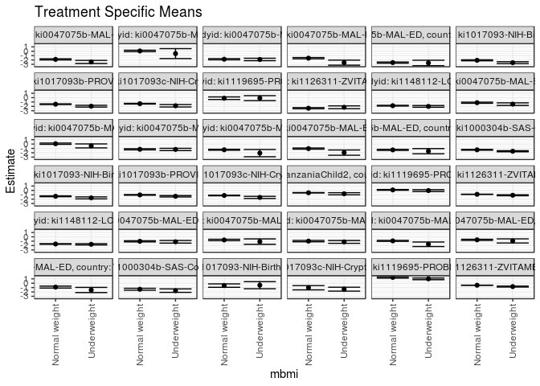

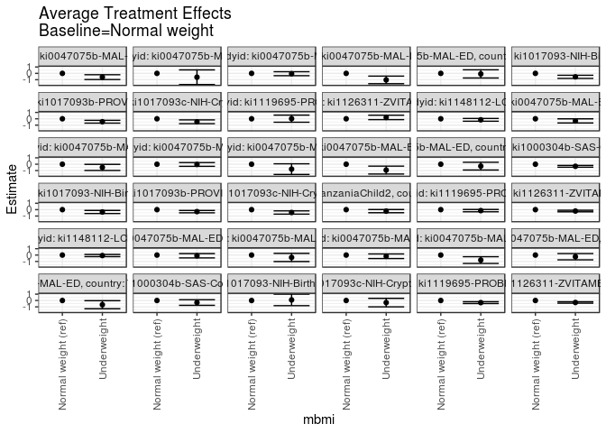

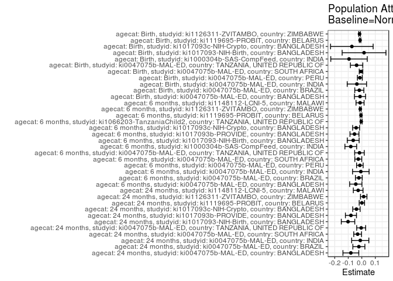

## Results Table

### Parameter: TSM

| agecat | studyid | country | intervention_level | baseline_level | estimate | ci_lower | ci_upper |
| --- | --- | --- | --- | --- | --- | --- | --- |
| Birth | ki0047075b-MAL-ED | BANGLADESH | Normal weight | NA | -1.0325463 | -1.1695561 | -0.8955365 |
| Birth | ki0047075b-MAL-ED | BANGLADESH | Underweight | NA | -1.1390000 | -1.4452579 | -0.8327421 |
| Birth | ki0047075b-MAL-ED | BRAZIL | Normal weight | NA | -0.7214286 | -0.8860242 | -0.5568330 |
| Birth | ki0047075b-MAL-ED | BRAZIL | Underweight | NA | -1.0955556 | -1.7166511 | -0.4744600 |
| Birth | ki0047075b-MAL-ED | INDIA | Normal weight | NA | -0.9838365 | -1.1420132 | -0.8256597 |
| Birth | ki0047075b-MAL-ED | INDIA | Underweight | NA | -1.1676923 | -1.4908414 | -0.8445432 |
| Birth | ki0047075b-MAL-ED | PERU | Normal weight | NA | -0.9244280 | -1.0379186 | -0.8109375 |
| Birth | ki0047075b-MAL-ED | PERU | Underweight | NA | -1.7080000 | -2.2260621 | -1.1899379 |
| Birth | ki0047075b-MAL-ED | SOUTH AFRICA | Normal weight | NA | -0.6865919 | -0.8189375 | -0.5542463 |
| Birth | ki0047075b-MAL-ED | SOUTH AFRICA | Underweight | NA | -0.9420000 | -1.4131562 | -0.4708438 |
| Birth | ki0047075b-MAL-ED | TANZANIA, UNITED REPUBLIC OF | Normal weight | NA | -0.8884211 | -1.1126576 | -0.6641845 |
| Birth | ki0047075b-MAL-ED | TANZANIA, UNITED REPUBLIC OF | Underweight | NA | -1.5514286 | -2.1432057 | -0.9596514 |
| Birth | ki1000304b-SAS-CompFeed | INDIA | Normal weight | NA | -1.3860440 | -1.6058982 | -1.1661897 |
| Birth | ki1000304b-SAS-CompFeed | INDIA | Underweight | NA | -1.7005128 | -2.0993883 | -1.3016373 |
| Birth | ki1017093-NIH-Birth | BANGLADESH | Normal weight | NA | -0.5460870 | -0.9370628 | -0.1551112 |
| Birth | ki1017093-NIH-Birth | BANGLADESH | Underweight | NA | -0.4520000 | -1.2667579 | 0.3627579 |
| Birth | ki1017093c-NIH-Crypto | BANGLADESH | Normal weight | NA | -1.0366667 | -1.5281526 | -0.5451807 |
| Birth | ki1017093c-NIH-Crypto | BANGLADESH | Underweight | NA | -1.3666667 | -1.8176632 | -0.9156702 |
| Birth | ki1119695-PROBIT | BELARUS | Normal weight | NA | 1.3390621 | 1.1794525 | 1.4986717 |
| Birth | ki1119695-PROBIT | BELARUS | Underweight | NA | 1.0052772 | 0.8117332 | 1.1988213 |
| Birth | ki1126311-ZVITAMBO | ZIMBABWE | Normal weight | NA | -0.4606883 | -0.4858072 | -0.4355694 |
| Birth | ki1126311-ZVITAMBO | ZIMBABWE | Underweight | NA | -0.7736667 | -0.8829885 | -0.6643448 |
| 6 months | ki0047075b-MAL-ED | BANGLADESH | Normal weight | NA | -1.1614195 | -1.2878037 | -1.0350352 |
| 6 months | ki0047075b-MAL-ED | BANGLADESH | Underweight | NA | -1.4947396 | -1.7942974 | -1.1951818 |
| 6 months | ki0047075b-MAL-ED | BRAZIL | Normal weight | NA | 0.0748995 | -0.0742030 | 0.2240020 |
| 6 months | ki0047075b-MAL-ED | BRAZIL | Underweight | NA | -0.4262963 | -0.8810079 | 0.0284153 |
| 6 months | ki0047075b-MAL-ED | INDIA | Normal weight | NA | -1.2077509 | -1.3405329 | -1.0749689 |
| 6 months | ki0047075b-MAL-ED | INDIA | Underweight | NA | -1.2417347 | -1.5031193 | -0.9803501 |
| 6 months | ki0047075b-MAL-ED | PERU | Normal weight | NA | -1.3131149 | -1.4218494 | -1.2043803 |
| 6 months | ki0047075b-MAL-ED | PERU | Underweight | NA | -2.0820000 | -2.9100519 | -1.2539481 |
| 6 months | ki0047075b-MAL-ED | SOUTH AFRICA | Normal weight | NA | -1.0469731 | -1.1780219 | -0.9159244 |
| 6 months | ki0047075b-MAL-ED | SOUTH AFRICA | Underweight | NA | -1.9657143 | -2.5717876 | -1.3596410 |
| 6 months | ki0047075b-MAL-ED | TANZANIA, UNITED REPUBLIC OF | Normal weight | NA | -1.3430258 | -1.4670388 | -1.2190127 |
| 6 months | ki0047075b-MAL-ED | TANZANIA, UNITED REPUBLIC OF | Underweight | NA | -1.6446429 | -2.2397609 | -1.0495248 |
| 6 months | ki1000304b-SAS-CompFeed | INDIA | Normal weight | NA | -1.3259056 | -1.4254990 | -1.2263123 |
| 6 months | ki1000304b-SAS-CompFeed | INDIA | Underweight | NA | -1.6530328 | -1.7747813 | -1.5312843 |
| 6 months | ki1017093-NIH-Birth | BANGLADESH | Normal weight | NA | -1.3439959 | -1.4393323 | -1.2486594 |
| 6 months | ki1017093-NIH-Birth | BANGLADESH | Underweight | NA | -1.7100000 | -1.9345841 | -1.4854159 |
| 6 months | ki1017093b-PROVIDE | BANGLADESH | Normal weight | NA | -1.0307623 | -1.1160686 | -0.9454560 |
| 6 months | ki1017093b-PROVIDE | BANGLADESH | Underweight | NA | -1.3424752 | -1.5036683 | -1.1812822 |
| 6 months | ki1017093c-NIH-Crypto | BANGLADESH | Normal weight | NA | -1.1568519 | -1.2307776 | -1.0829261 |
| 6 months | ki1017093c-NIH-Crypto | BANGLADESH | Underweight | NA | -1.6032090 | -1.8466359 | -1.3597820 |
| 6 months | ki1066203-TanzaniaChild2 | TANZANIA, UNITED REPUBLIC OF | Normal weight | NA | -0.5365944 | -0.5868803 | -0.4863086 |
| 6 months | ki1066203-TanzaniaChild2 | TANZANIA, UNITED REPUBLIC OF | Underweight | NA | -0.7685294 | -1.0128208 | -0.5242380 |
| 6 months | ki1119695-PROBIT | BELARUS | Normal weight | NA | 0.1213488 | 0.0290866 | 0.2136111 |
| 6 months | ki1119695-PROBIT | BELARUS | Underweight | NA | -0.0328020 | -0.2462930 | 0.1806891 |
| 6 months | ki1126311-ZVITAMBO | ZIMBABWE | Normal weight | NA | -0.8898014 | -0.9182582 | -0.8613446 |
| 6 months | ki1126311-ZVITAMBO | ZIMBABWE | Underweight | NA | -1.1072790 | -1.2259342 | -0.9886238 |
| 6 months | ki1148112-LCNI-5 | MALAWI | Normal weight | NA | -1.6449928 | -1.7230655 | -1.5669201 |
| 6 months | ki1148112-LCNI-5 | MALAWI | Underweight | NA | -1.7186897 | -1.8709913 | -1.5663880 |
| 24 months | ki0047075b-MAL-ED | BANGLADESH | Normal weight | NA | -1.8624317 | -1.9933973 | -1.7314661 |
| 24 months | ki0047075b-MAL-ED | BANGLADESH | Underweight | NA | -2.4522414 | -2.8074899 | -2.0969928 |
| 24 months | ki0047075b-MAL-ED | BRAZIL | Normal weight | NA | 0.0633642 | -0.1049962 | 0.2317246 |
| 24 months | ki0047075b-MAL-ED | BRAZIL | Underweight | NA | -0.5391667 | -1.6773310 | 0.5989977 |
| 24 months | ki0047075b-MAL-ED | INDIA | Normal weight | NA | -1.8325833 | -1.9747434 | -1.6904232 |
| 24 months | ki0047075b-MAL-ED | INDIA | Underweight | NA | -1.8882609 | -2.1656962 | -1.6108256 |
| 24 months | ki0047075b-MAL-ED | SOUTH AFRICA | Normal weight | NA | -1.5912775 | -1.7294629 | -1.4530921 |
| 24 months | ki0047075b-MAL-ED | SOUTH AFRICA | Underweight | NA | -2.6192857 | -3.1998173 | -2.0387542 |
| 24 months | ki0047075b-MAL-ED | TANZANIA, UNITED REPUBLIC OF | Normal weight | NA | -2.6014778 | -2.7389925 | -2.4639631 |
| 24 months | ki0047075b-MAL-ED | TANZANIA, UNITED REPUBLIC OF | Underweight | NA | -2.6872727 | -3.3161985 | -2.0583469 |
| 24 months | ki1017093-NIH-Birth | BANGLADESH | Normal weight | NA | -2.0791046 | -2.1926548 | -1.9655544 |
| 24 months | ki1017093-NIH-Birth | BANGLADESH | Underweight | NA | -2.6244167 | -2.8408427 | -2.4079907 |
| 24 months | ki1017093b-PROVIDE | BANGLADESH | Normal weight | NA | -1.5037605 | -1.5935271 | -1.4139939 |
| 24 months | ki1017093b-PROVIDE | BANGLADESH | Underweight | NA | -1.9655000 | -2.1673962 | -1.7636038 |
| 24 months | ki1017093c-NIH-Crypto | BANGLADESH | Normal weight | NA | -1.3900637 | -1.4762251 | -1.3039023 |
| 24 months | ki1017093c-NIH-Crypto | BANGLADESH | Underweight | NA | -1.8618605 | -2.1465984 | -1.5771225 |
| 24 months | ki1119695-PROBIT | BELARUS | Normal weight | NA | -0.1329261 | -0.4352880 | 0.1694359 |
| 24 months | ki1119695-PROBIT | BELARUS | Underweight | NA | -0.1129577 | -0.6758113 | 0.4498958 |
| 24 months | ki1126311-ZVITAMBO | ZIMBABWE | Normal weight | NA | -2.4277273 | -2.5574485 | -2.2980060 |
| 24 months | ki1126311-ZVITAMBO | ZIMBABWE | Underweight | NA | -2.2136000 | -2.5403202 | -1.8868798 |
| 24 months | ki1148112-LCNI-5 | MALAWI | Normal weight | NA | -1.8477593 | -1.9367961 | -1.7587226 |
| 24 months | ki1148112-LCNI-5 | MALAWI | Underweight | NA | -2.0097895 | -2.2059979 | -1.8135811 |

### Parameter: E(Y)

| agecat | studyid | country | intervention_level | baseline_level | estimate | ci_lower | ci_upper |
| --- | --- | --- | --- | --- | --- | --- | --- |
| Birth | ki0047075b-MAL-ED | BANGLADESH | NA | NA | -1.0455285 | -1.1715695 | -0.9194875 |
| Birth | ki0047075b-MAL-ED | BRAZIL | NA | NA | -0.7397283 | -0.8996215 | -0.5798350 |
| Birth | ki0047075b-MAL-ED | INDIA | NA | NA | -1.0200505 | -1.1624932 | -0.8776078 |
| Birth | ki0047075b-MAL-ED | PERU | NA | NA | -0.9386232 | -1.0507144 | -0.8265319 |
| Birth | ki0047075b-MAL-ED | SOUTH AFRICA | NA | NA | -0.6921930 | -0.8218578 | -0.5625282 |
| Birth | ki0047075b-MAL-ED | TANZANIA, UNITED REPUBLIC OF | NA | NA | -0.9267769 | -1.1425813 | -0.7109724 |
| Birth | ki1000304b-SAS-CompFeed | INDIA | NA | NA | -1.4803846 | -1.6742160 | -1.2865532 |
| Birth | ki1017093-NIH-Birth | BANGLADESH | NA | NA | -0.5292857 | -0.8821252 | -0.1764462 |
| Birth | ki1017093c-NIH-Crypto | BANGLADESH | NA | NA | -1.1100000 | -1.5086894 | -0.7113106 |
| Birth | ki1119695-PROBIT | BELARUS | NA | NA | 1.3263412 | 1.1672322 | 1.4854501 |
| Birth | ki1126311-ZVITAMBO | ZIMBABWE | NA | NA | -0.4772566 | -0.5017796 | -0.4527336 |
| 6 months | ki0047075b-MAL-ED | BANGLADESH | NA | NA | -1.2056777 | -1.3231497 | -1.0882058 |
| 6 months | ki0047075b-MAL-ED | BRAZIL | NA | NA | 0.0532131 | -0.0914567 | 0.1978830 |
| 6 months | ki0047075b-MAL-ED | INDIA | NA | NA | -1.2148369 | -1.3332371 | -1.0964367 |
| 6 months | ki0047075b-MAL-ED | PERU | NA | NA | -1.3272488 | -1.4359649 | -1.2185326 |
| 6 months | ki0047075b-MAL-ED | SOUTH AFRICA | NA | NA | -1.0728012 | -1.2026830 | -0.9429194 |
| 6 months | ki0047075b-MAL-ED | TANZANIA, UNITED REPUBLIC OF | NA | NA | -1.3601215 | -1.4821830 | -1.2380600 |
| 6 months | ki1000304b-SAS-CompFeed | INDIA | NA | NA | -1.4072209 | -1.4983514 | -1.3160903 |
| 6 months | ki1017093-NIH-Birth | BANGLADESH | NA | NA | -1.4073821 | -1.4960598 | -1.3187043 |
| 6 months | ki1017093b-PROVIDE | BANGLADESH | NA | NA | -1.0848568 | -1.1613109 | -1.0084028 |
| 6 months | ki1017093c-NIH-Crypto | BANGLADESH | NA | NA | -1.1986783 | -1.2700937 | -1.1272630 |
| 6 months | ki1066203-TanzaniaChild2 | TANZANIA, UNITED REPUBLIC OF | NA | NA | -0.5405711 | -0.5899965 | -0.4911457 |
| 6 months | ki1119695-PROBIT | BELARUS | NA | NA | 0.1153731 | 0.0222128 | 0.2085334 |
| 6 months | ki1126311-ZVITAMBO | ZIMBABWE | NA | NA | -0.9008757 | -0.9285733 | -0.8731780 |
| 6 months | ki1148112-LCNI-5 | MALAWI | NA | NA | -1.6577751 | -1.7275296 | -1.5880207 |
| 24 months | ki0047075b-MAL-ED | BANGLADESH | NA | NA | -1.9431132 | -2.0691678 | -1.8170586 |
| 24 months | ki0047075b-MAL-ED | BRAZIL | NA | NA | 0.0418452 | -0.1263708 | 0.2100613 |
| 24 months | ki0047075b-MAL-ED | INDIA | NA | NA | -1.8439159 | -1.9704751 | -1.7173568 |
| 24 months | ki0047075b-MAL-ED | SOUTH AFRICA | NA | NA | -1.6220299 | -1.7590593 | -1.4850005 |
| 24 months | ki0047075b-MAL-ED | TANZANIA, UNITED REPUBLIC OF | NA | NA | -2.6058879 | -2.7403043 | -2.4714714 |
| 24 months | ki1017093-NIH-Birth | BANGLADESH | NA | NA | -2.1807945 | -2.2835902 | -2.0779987 |
| 24 months | ki1017093b-PROVIDE | BANGLADESH | NA | NA | -1.5839236 | -1.6672059 | -1.5006413 |
| 24 months | ki1017093c-NIH-Crypto | BANGLADESH | NA | NA | -1.4295331 | -1.5127726 | -1.3462935 |
| 24 months | ki1119695-PROBIT | BELARUS | NA | NA | -0.1322181 | -0.4300523 | 0.1656161 |
| 24 months | ki1126311-ZVITAMBO | ZIMBABWE | NA | NA | -2.4135279 | -2.5366872 | -2.2903685 |
| 24 months | ki1148112-LCNI-5 | MALAWI | NA | NA | -1.8744367 | -1.9556750 | -1.7931984 |

### Parameter: ATE

| agecat | studyid | country | intervention_level | baseline_level | estimate | ci_lower | ci_upper |
| --- | --- | --- | --- | --- | --- | --- | --- |
| Birth | ki0047075b-MAL-ED | BANGLADESH | Normal weight | Normal weight | 0.0000000 | 0.0000000 | 0.0000000 |
| Birth | ki0047075b-MAL-ED | BANGLADESH | Underweight | Normal weight | -0.1064537 | -0.4419616 | 0.2290542 |
| Birth | ki0047075b-MAL-ED | BRAZIL | Normal weight | Normal weight | 0.0000000 | 0.0000000 | 0.0000000 |
| Birth | ki0047075b-MAL-ED | BRAZIL | Underweight | Normal weight | -0.3741270 | -1.0166621 | 0.2684082 |
| Birth | ki0047075b-MAL-ED | INDIA | Normal weight | Normal weight | 0.0000000 | 0.0000000 | 0.0000000 |
| Birth | ki0047075b-MAL-ED | INDIA | Underweight | Normal weight | -0.1838558 | -0.5436408 | 0.1759291 |
| Birth | ki0047075b-MAL-ED | PERU | Normal weight | Normal weight | 0.0000000 | 0.0000000 | 0.0000000 |
| Birth | ki0047075b-MAL-ED | PERU | Underweight | Normal weight | -0.7835720 | -1.3139194 | -0.2532245 |
| Birth | ki0047075b-MAL-ED | SOUTH AFRICA | Normal weight | Normal weight | 0.0000000 | 0.0000000 | 0.0000000 |
| Birth | ki0047075b-MAL-ED | SOUTH AFRICA | Underweight | Normal weight | -0.2554081 | -0.7447990 | 0.2339829 |
| Birth | ki0047075b-MAL-ED | TANZANIA, UNITED REPUBLIC OF | Normal weight | Normal weight | 0.0000000 | 0.0000000 | 0.0000000 |
| Birth | ki0047075b-MAL-ED | TANZANIA, UNITED REPUBLIC OF | Underweight | Normal weight | -0.6630075 | -1.2958441 | -0.0301709 |
| Birth | ki1000304b-SAS-CompFeed | INDIA | Normal weight | Normal weight | 0.0000000 | 0.0000000 | 0.0000000 |
| Birth | ki1000304b-SAS-CompFeed | INDIA | Underweight | Normal weight | -0.3144689 | -0.7570653 | 0.1281276 |
| Birth | ki1017093-NIH-Birth | BANGLADESH | Normal weight | Normal weight | 0.0000000 | 0.0000000 | 0.0000000 |
| Birth | ki1017093-NIH-Birth | BANGLADESH | Underweight | Normal weight | 0.0940870 | -0.8096235 | 0.9977974 |
| Birth | ki1017093c-NIH-Crypto | BANGLADESH | Normal weight | Normal weight | 0.0000000 | 0.0000000 | 0.0000000 |
| Birth | ki1017093c-NIH-Crypto | BANGLADESH | Underweight | Normal weight | -0.3300000 | -0.9970504 | 0.3370504 |
| Birth | ki1119695-PROBIT | BELARUS | Normal weight | Normal weight | 0.0000000 | 0.0000000 | 0.0000000 |
| Birth | ki1119695-PROBIT | BELARUS | Underweight | Normal weight | -0.3337849 | -0.4780844 | -0.1894853 |
| Birth | ki1126311-ZVITAMBO | ZIMBABWE | Normal weight | Normal weight | 0.0000000 | 0.0000000 | 0.0000000 |
| Birth | ki1126311-ZVITAMBO | ZIMBABWE | Underweight | Normal weight | -0.3129784 | -0.4251489 | -0.2008078 |
| 6 months | ki0047075b-MAL-ED | BANGLADESH | Normal weight | Normal weight | 0.0000000 | 0.0000000 | 0.0000000 |
| 6 months | ki0047075b-MAL-ED | BANGLADESH | Underweight | Normal weight | -0.3333201 | -0.6584476 | -0.0081927 |
| 6 months | ki0047075b-MAL-ED | BRAZIL | Normal weight | Normal weight | 0.0000000 | 0.0000000 | 0.0000000 |
| 6 months | ki0047075b-MAL-ED | BRAZIL | Underweight | Normal weight | -0.5011958 | -0.9797291 | -0.0226625 |
| 6 months | ki0047075b-MAL-ED | INDIA | Normal weight | Normal weight | 0.0000000 | 0.0000000 | 0.0000000 |
| 6 months | ki0047075b-MAL-ED | INDIA | Underweight | Normal weight | -0.0339838 | -0.3271612 | 0.2591936 |
| 6 months | ki0047075b-MAL-ED | PERU | Normal weight | Normal weight | 0.0000000 | 0.0000000 | 0.0000000 |
| 6 months | ki0047075b-MAL-ED | PERU | Underweight | Normal weight | -0.7688851 | -1.6040457 | 0.0662754 |
| 6 months | ki0047075b-MAL-ED | SOUTH AFRICA | Normal weight | Normal weight | 0.0000000 | 0.0000000 | 0.0000000 |
| 6 months | ki0047075b-MAL-ED | SOUTH AFRICA | Underweight | Normal weight | -0.9187411 | -1.5388207 | -0.2986616 |
| 6 months | ki0047075b-MAL-ED | TANZANIA, UNITED REPUBLIC OF | Normal weight | Normal weight | 0.0000000 | 0.0000000 | 0.0000000 |
| 6 months | ki0047075b-MAL-ED | TANZANIA, UNITED REPUBLIC OF | Underweight | Normal weight | -0.3016171 | -0.9095190 | 0.3062848 |
| 6 months | ki1000304b-SAS-CompFeed | INDIA | Normal weight | Normal weight | 0.0000000 | 0.0000000 | 0.0000000 |
| 6 months | ki1000304b-SAS-CompFeed | INDIA | Underweight | Normal weight | -0.3271271 | -0.4684775 | -0.1857768 |
| 6 months | ki1017093-NIH-Birth | BANGLADESH | Normal weight | Normal weight | 0.0000000 | 0.0000000 | 0.0000000 |
| 6 months | ki1017093-NIH-Birth | BANGLADESH | Underweight | Normal weight | -0.3660041 | -0.6099858 | -0.1220224 |
| 6 months | ki1017093b-PROVIDE | BANGLADESH | Normal weight | Normal weight | 0.0000000 | 0.0000000 | 0.0000000 |
| 6 months | ki1017093b-PROVIDE | BANGLADESH | Underweight | Normal weight | -0.3117129 | -0.4940872 | -0.1293387 |
| 6 months | ki1017093c-NIH-Crypto | BANGLADESH | Normal weight | Normal weight | 0.0000000 | 0.0000000 | 0.0000000 |
| 6 months | ki1017093c-NIH-Crypto | BANGLADESH | Underweight | Normal weight | -0.4463571 | -0.7007617 | -0.1919525 |
| 6 months | ki1066203-TanzaniaChild2 | TANZANIA, UNITED REPUBLIC OF | Normal weight | Normal weight | 0.0000000 | 0.0000000 | 0.0000000 |
| 6 months | ki1066203-TanzaniaChild2 | TANZANIA, UNITED REPUBLIC OF | Underweight | Normal weight | -0.2319350 | -0.4813482 | 0.0174782 |
| 6 months | ki1119695-PROBIT | BELARUS | Normal weight | Normal weight | 0.0000000 | 0.0000000 | 0.0000000 |
| 6 months | ki1119695-PROBIT | BELARUS | Underweight | Normal weight | -0.1541508 | -0.3357169 | 0.0274153 |
| 6 months | ki1126311-ZVITAMBO | ZIMBABWE | Normal weight | Normal weight | 0.0000000 | 0.0000000 | 0.0000000 |
| 6 months | ki1126311-ZVITAMBO | ZIMBABWE | Underweight | Normal weight | -0.2174776 | -0.3394975 | -0.0954577 |
| 6 months | ki1148112-LCNI-5 | MALAWI | Normal weight | Normal weight | 0.0000000 | 0.0000000 | 0.0000000 |
| 6 months | ki1148112-LCNI-5 | MALAWI | Underweight | Normal weight | -0.0736969 | -0.2448434 | 0.0974496 |
| 24 months | ki0047075b-MAL-ED | BANGLADESH | Normal weight | Normal weight | 0.0000000 | 0.0000000 | 0.0000000 |
| 24 months | ki0047075b-MAL-ED | BANGLADESH | Underweight | Normal weight | -0.5898097 | -0.9684302 | -0.2111891 |
| 24 months | ki0047075b-MAL-ED | BRAZIL | Normal weight | Normal weight | 0.0000000 | 0.0000000 | 0.0000000 |
| 24 months | ki0047075b-MAL-ED | BRAZIL | Underweight | Normal weight | -0.6025309 | -1.7530800 | 0.5480183 |
| 24 months | ki0047075b-MAL-ED | INDIA | Normal weight | Normal weight | 0.0000000 | 0.0000000 | 0.0000000 |
| 24 months | ki0047075b-MAL-ED | INDIA | Underweight | Normal weight | -0.0556775 | -0.3674144 | 0.2560593 |
| 24 months | ki0047075b-MAL-ED | SOUTH AFRICA | Normal weight | Normal weight | 0.0000000 | 0.0000000 | 0.0000000 |
| 24 months | ki0047075b-MAL-ED | SOUTH AFRICA | Underweight | Normal weight | -1.0280082 | -1.6247594 | -0.4312569 |
| 24 months | ki0047075b-MAL-ED | TANZANIA, UNITED REPUBLIC OF | Normal weight | Normal weight | 0.0000000 | 0.0000000 | 0.0000000 |
| 24 months | ki0047075b-MAL-ED | TANZANIA, UNITED REPUBLIC OF | Underweight | Normal weight | -0.0857949 | -0.7295790 | 0.5579892 |
| 24 months | ki1017093-NIH-Birth | BANGLADESH | Normal weight | Normal weight | 0.0000000 | 0.0000000 | 0.0000000 |
| 24 months | ki1017093-NIH-Birth | BANGLADESH | Underweight | Normal weight | -0.5453121 | -0.7897172 | -0.3009070 |
| 24 months | ki1017093b-PROVIDE | BANGLADESH | Normal weight | Normal weight | 0.0000000 | 0.0000000 | 0.0000000 |
| 24 months | ki1017093b-PROVIDE | BANGLADESH | Underweight | Normal weight | -0.4617395 | -0.6826922 | -0.2407868 |
| 24 months | ki1017093c-NIH-Crypto | BANGLADESH | Normal weight | Normal weight | 0.0000000 | 0.0000000 | 0.0000000 |
| 24 months | ki1017093c-NIH-Crypto | BANGLADESH | Underweight | Normal weight | -0.4717968 | -0.7692854 | -0.1743081 |
| 24 months | ki1119695-PROBIT | BELARUS | Normal weight | Normal weight | 0.0000000 | 0.0000000 | 0.0000000 |
| 24 months | ki1119695-PROBIT | BELARUS | Underweight | Normal weight | 0.0199683 | -0.5387653 | 0.5787019 |
| 24 months | ki1126311-ZVITAMBO | ZIMBABWE | Normal weight | Normal weight | 0.0000000 | 0.0000000 | 0.0000000 |
| 24 months | ki1126311-ZVITAMBO | ZIMBABWE | Underweight | Normal weight | 0.2141273 | -0.1374032 | 0.5656578 |
| 24 months | ki1148112-LCNI-5 | MALAWI | Normal weight | Normal weight | 0.0000000 | 0.0000000 | 0.0000000 |
| 24 months | ki1148112-LCNI-5 | MALAWI | Underweight | Normal weight | -0.1620301 | -0.3774954 | 0.0534351 |

### Parameter: PAR

| agecat | studyid | country | intervention_level | baseline_level | estimate | ci_lower | ci_upper |
| --- | --- | --- | --- | --- | --- | --- | --- |
| Birth | ki0047075b-MAL-ED | BANGLADESH | Normal weight | NA | -0.0129822 | -0.0541296 | 0.0281653 |
| Birth | ki0047075b-MAL-ED | BRAZIL | Normal weight | NA | -0.0182997 | -0.0518322 | 0.0152328 |
| Birth | ki0047075b-MAL-ED | INDIA | Normal weight | NA | -0.0362140 | -0.1078126 | 0.0353845 |
| Birth | ki0047075b-MAL-ED | PERU | Normal weight | NA | -0.0141951 | -0.0323157 | 0.0039254 |
| Birth | ki0047075b-MAL-ED | SOUTH AFRICA | Normal weight | NA | -0.0056011 | -0.0187680 | 0.0075659 |
| Birth | ki0047075b-MAL-ED | TANZANIA, UNITED REPUBLIC OF | Normal weight | NA | -0.0383558 | -0.0842611 | 0.0075495 |
| Birth | ki1000304b-SAS-CompFeed | INDIA | Normal weight | NA | -0.0943407 | -0.2291991 | 0.0405177 |
| Birth | ki1017093-NIH-Birth | BANGLADESH | Normal weight | NA | 0.0168012 | -0.1451470 | 0.1787495 |
| Birth | ki1017093c-NIH-Crypto | BANGLADESH | Normal weight | NA | -0.0733333 | -0.2306677 | 0.0840010 |
| Birth | ki1119695-PROBIT | BELARUS | Normal weight | NA | -0.0127209 | -0.0180133 | -0.0074286 |
| Birth | ki1126311-ZVITAMBO | ZIMBABWE | Normal weight | NA | -0.0165683 | -0.0226690 | -0.0104676 |
| 6 months | ki0047075b-MAL-ED | BANGLADESH | Normal weight | NA | -0.0442583 | -0.0897386 | 0.0012220 |
| 6 months | ki0047075b-MAL-ED | BRAZIL | Normal weight | NA | -0.0216864 | -0.0466204 | 0.0032477 |
| 6 months | ki0047075b-MAL-ED | INDIA | Normal weight | NA | -0.0070860 | -0.0682422 | 0.0540702 |
| 6 months | ki0047075b-MAL-ED | PERU | Normal weight | NA | -0.0141339 | -0.0383650 | 0.0100972 |
| 6 months | ki0047075b-MAL-ED | SOUTH AFRICA | Normal weight | NA | -0.0258281 | -0.0515400 | -0.0001162 |
| 6 months | ki0047075b-MAL-ED | TANZANIA, UNITED REPUBLIC OF | Normal weight | NA | -0.0170957 | -0.0526368 | 0.0184454 |
| 6 months | ki1000304b-SAS-CompFeed | INDIA | Normal weight | NA | -0.0813152 | -0.1247301 | -0.0379003 |
| 6 months | ki1017093-NIH-Birth | BANGLADESH | Normal weight | NA | -0.0633862 | -0.1072366 | -0.0195358 |
| 6 months | ki1017093b-PROVIDE | BANGLADESH | Normal weight | NA | -0.0540945 | -0.0871673 | -0.0210217 |
| 6 months | ki1017093c-NIH-Crypto | BANGLADESH | Normal weight | NA | -0.0418265 | -0.0675042 | -0.0161487 |
| 6 months | ki1066203-TanzaniaChild2 | TANZANIA, UNITED REPUBLIC OF | Normal weight | NA | -0.0039767 | -0.0103514 | 0.0023980 |
| 6 months | ki1119695-PROBIT | BELARUS | Normal weight | NA | -0.0059758 | -0.0128267 | 0.0008752 |
| 6 months | ki1126311-ZVITAMBO | ZIMBABWE | Normal weight | NA | -0.0110743 | -0.0173863 | -0.0047622 |
| 6 months | ki1148112-LCNI-5 | MALAWI | Normal weight | NA | -0.0127824 | -0.0425271 | 0.0169624 |
| 24 months | ki0047075b-MAL-ED | BANGLADESH | Normal weight | NA | -0.0806815 | -0.1392503 | -0.0221127 |
| 24 months | ki0047075b-MAL-ED | BRAZIL | Normal weight | NA | -0.0215190 | -0.0659720 | 0.0229341 |
| 24 months | ki0047075b-MAL-ED | INDIA | Normal weight | NA | -0.0113326 | -0.0748510 | 0.0521858 |
| 24 months | ki0047075b-MAL-ED | SOUTH AFRICA | Normal weight | NA | -0.0307524 | -0.0594630 | -0.0020418 |
| 24 months | ki0047075b-MAL-ED | TANZANIA, UNITED REPUBLIC OF | Normal weight | NA | -0.0044100 | -0.0375994 | 0.0287793 |
| 24 months | ki1017093-NIH-Birth | BANGLADESH | Normal weight | NA | -0.1016899 | -0.1515109 | -0.0518689 |
| 24 months | ki1017093b-PROVIDE | BANGLADESH | Normal weight | NA | -0.0801631 | -0.1211000 | -0.0392262 |
| 24 months | ki1017093c-NIH-Crypto | BANGLADESH | Normal weight | NA | -0.0394694 | -0.0668034 | -0.0121354 |
| 24 months | ki1119695-PROBIT | BELARUS | Normal weight | NA | 0.0007080 | -0.0190786 | 0.0204946 |
| 24 months | ki1126311-ZVITAMBO | ZIMBABWE | Normal weight | NA | 0.0141994 | -0.0097256 | 0.0381245 |
| 24 months | ki1148112-LCNI-5 | MALAWI | Normal weight | NA | -0.0266774 | -0.0624904 | 0.0091356 |